# Linear Regression Analysis

- Describe your work and results clearly.
- Assume the reader has an introductory course level understanding of writing and reading R code as well as statistical methods.
- Assume the reader has no previous knowledge of your data or the more advanced methods you are using.

## Loading required packages

```r
library(tidyverse)
```

```r
library(ggplot2)
```

## Step 1

## Reading data

```r
students2014 <- read.csv("Data/learning2014.csv")

dim(students2014)
```

```
## [1] 166   7
```

```r
str(students2014)
```

```
## 'data.frame':    166 obs. of  7 variables:
##  $ gender  : chr  "F" "M" "F" "M" ...
##  $ age     : int  53 55 49 53 49 38 50 37 37 42 ...
##  $ attitude: num  3.7 3.1 2.5 3.5 3.7 3.8 3.5 2.9 3.8 2.1 ...
##  $ deep    : num  3.58 2.92 3.5 3.5 3.67 ...
##  $ stra    : num  3.38 2.75 3.62 3.12 3.62 ...
##  $ surf    : num  2.58 3.17 2.25 2.25 2.83 ...
##  $ points  : int  25 12 24 10 22 21 21 31 24 26 ...
```

In this data set, 166 observations of 7 variables are available. This data set tells about the points obtained from a group of people through answering some questionnaires. Group of people were categorized based on gender, age and attitude, additionally questionnaires were categorized into: (1) deep questions which variable name is “deep”, (2) surface questions, which variable name is “surf” and (3) strategic question, which variable name is “stra”.

## Step 2

### Graphical overview

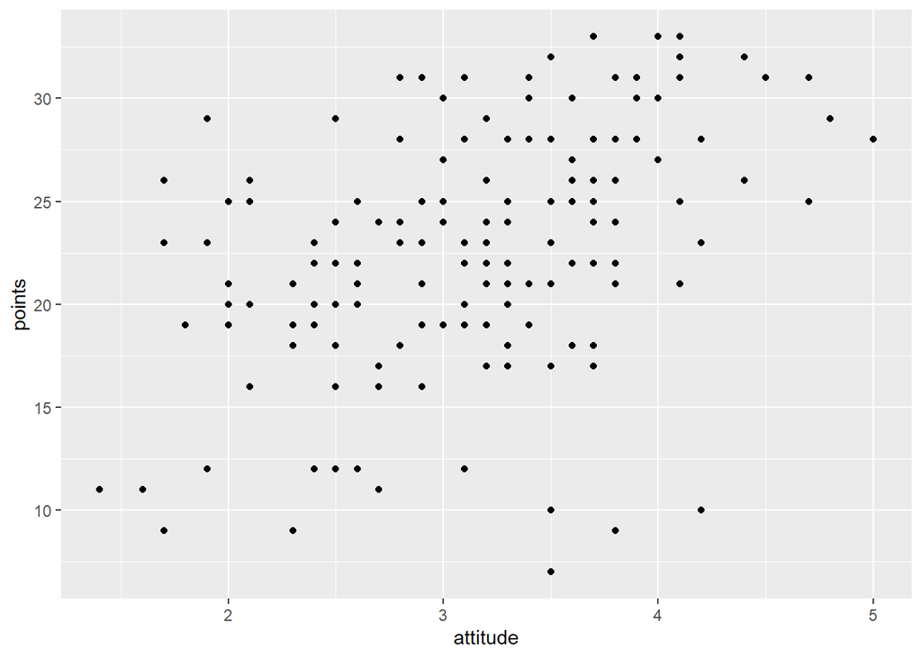

```r
# Access the gglot2 library
library(ggplot2)

# initialize plot with data and aesthetic mapping
p1 <- ggplot(students2014, aes(x = attitude, y = points))

# define the visualization type (points)
p2 <- p1 + geom_point()

# draw the plot
p2
```

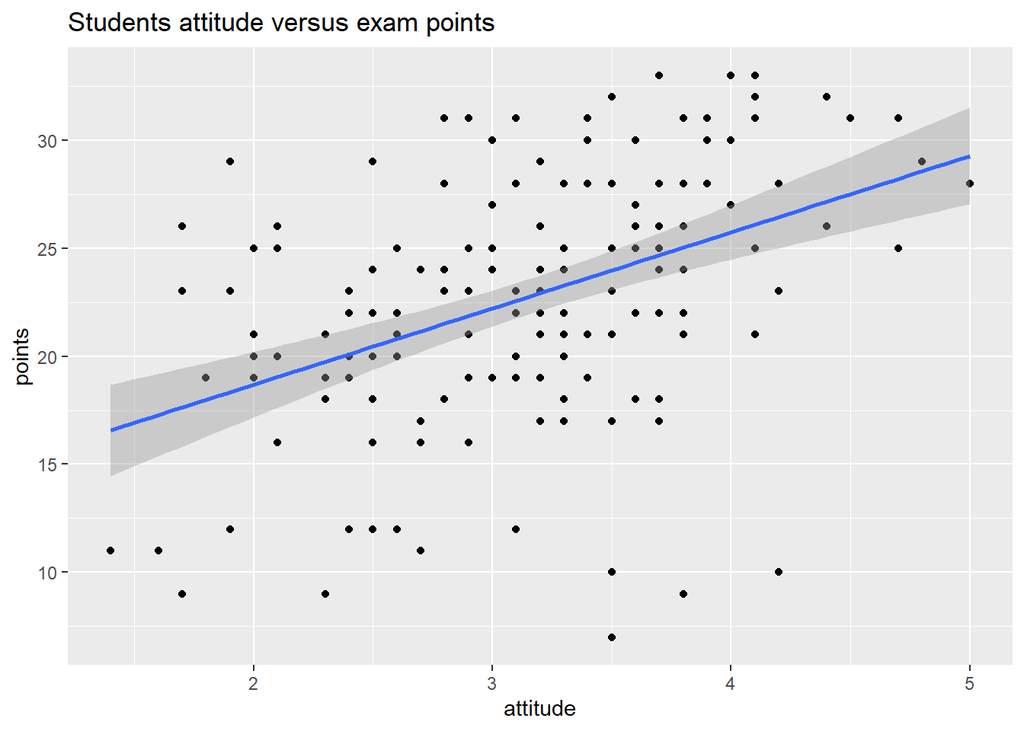

```r
# add a regression line
p3 <- p2 + geom_smooth(method = "lm")

# add a main title
p4 <- p3 + ggtitle('Students attitude versus exam points')

p4
```

This above scatter plots indicates the linear relationship between points and attitude.

### Grafical views with all the variables

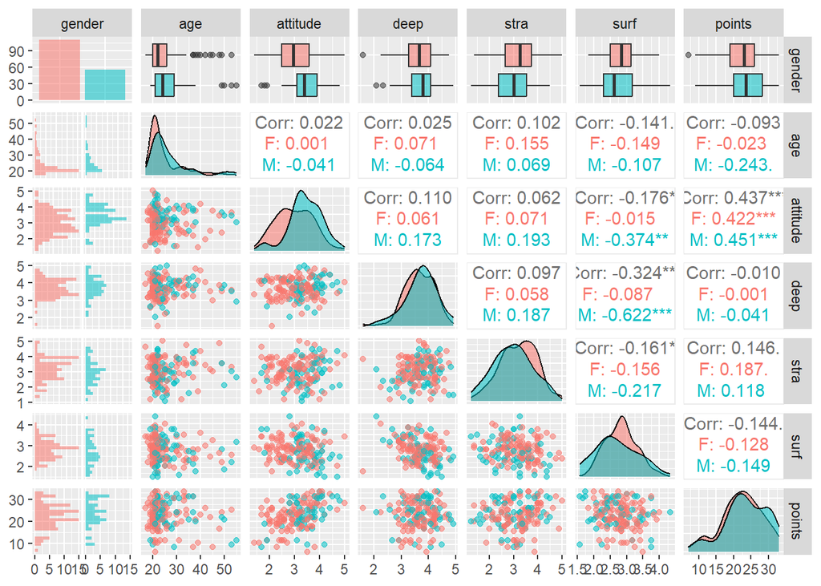

```r
# access the GGally and ggplot2 libraries
library(GGally)
library(ggplot2)
# create a more advanced plot matrix with ggpairs()
p <- ggpairs(students2014, mapping = aes(col = gender, alpha = 0.3), lower = list(combo = wrap("facethist", bins = 20)))

p
```

## Step 3

### Regression model

```r
# fit a linear model
my_model1 <- lm(points ~ gender + age + attitude, data = students2014)
summary(my_model1)
```

```
##
## Call:
## lm(formula = points ~ gender + age + attitude, data = students2014)
##
## Residuals:
##      Min       1Q   Median       3Q      Max
## -17.4590  -3.3221   0.2186   4.0247  10.4632
##
## Coefficients:
##             Estimate Std. Error t value Pr(>|t|)
## (Intercept) 13.42910    2.29043   5.863 2.48e-08 ***
## genderM     -0.33054    0.91934  -0.360    0.720
## age         -0.07586    0.05367  -1.414    0.159
## attitude     3.60657    0.59322   6.080 8.34e-09 ***
## ---
## Signif. codes:  0 '***' 0.001 '**' 0.01 '*' 0.05 '.' 0.1 ' ' 1
##
## Residual standard error: 5.315 on 162 degrees of freedom
## Multiple R-squared:  0.2018, Adjusted R-squared:  0.187
## F-statistic: 13.65 on 3 and 162 DF,  p-value: 5.536e-08
```

Here only attitude is significant. So I will exclude other insignificant variables.

```r
# Second model
my_model2 <- lm(points ~ attitude + deep + stra, data = students2014)
summary(my_model2)
```

```
##
## Call:
## lm(formula = points ~ attitude + deep + stra, data = students2014)
##
## Residuals:
##      Min       1Q   Median       3Q      Max
## -17.5239  -3.4276   0.5474   3.8220  11.5112
##
## Coefficients:
##             Estimate Std. Error t value Pr(>|t|)
## (Intercept)  11.3915     3.4077   3.343  0.00103 **
## attitude      3.5254     0.5683   6.203 4.44e-09 ***
## deep         -0.7492     0.7507  -0.998  0.31974
## stra          0.9621     0.5367   1.793  0.07489 .
## ---
## Signif. codes:  0 '***' 0.001 '**' 0.01 '*' 0.05 '.' 0.1 ' ' 1
##
## Residual standard error: 5.289 on 162 degrees of freedom
## Multiple R-squared:  0.2097, Adjusted R-squared:  0.195
## F-statistic: 14.33 on 3 and 162 DF,  p-value: 2.521e-08
```

```r
# Final model
final_model <- lm(points ~ attitude + stra, data = students2014)
summary(final_model)
```

```
##
## Call:
## lm(formula = points ~ attitude + stra, data = students2014)
##
## Residuals:
##      Min       1Q   Median       3Q      Max
## -17.6436  -3.3113   0.5575   3.7928  10.9295
##
## Coefficients:
##             Estimate Std. Error t value Pr(>|t|)
## (Intercept)   8.9729     2.3959   3.745  0.00025 ***
## attitude      3.4658     0.5652   6.132 6.31e-09 ***
## stra          0.9137     0.5345   1.709  0.08927 .
## ---
## Signif. codes:  0 '***' 0.001 '**' 0.01 '*' 0.05 '.' 0.1 ' ' 1
##
## Residual standard error: 5.289 on 163 degrees of freedom
## Multiple R-squared:  0.2048, Adjusted R-squared:  0.1951
## F-statistic: 20.99 on 2 and 163 DF,  p-value: 7.734e-09
```

## Step 4

### The linear regression equation and explation of equation based on fitted model

Points = 8.9729 + 3.4658 * attitude + 0.9137 * stra

intercept = 8.9729 is the obtained points for the people, irrespective to attitude and strategic question.

attitude slope = 3.4658 is the additional points for the people who has attitude

stra slope = 0.9137 is the difference of points between strategic question and non strategic question who has attitude

Additionally, from the Adjusted R-squared value, we can say that 19% of variation has been explained by this model.

## Step 5

### Checking the assumptions of the model

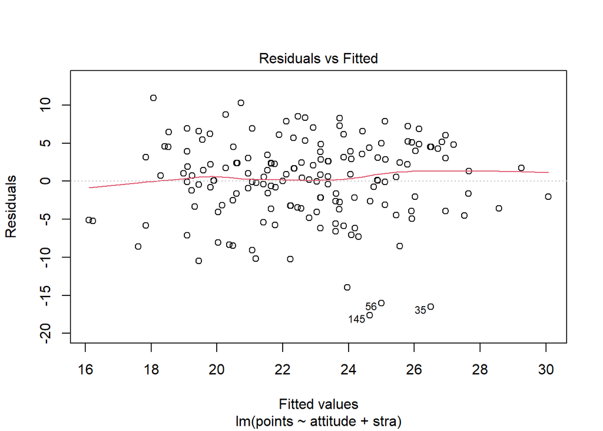

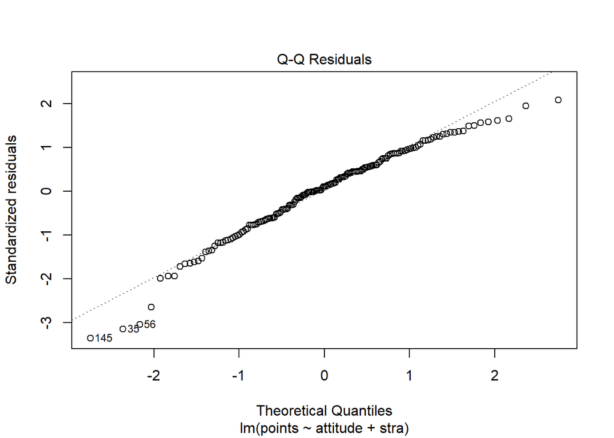

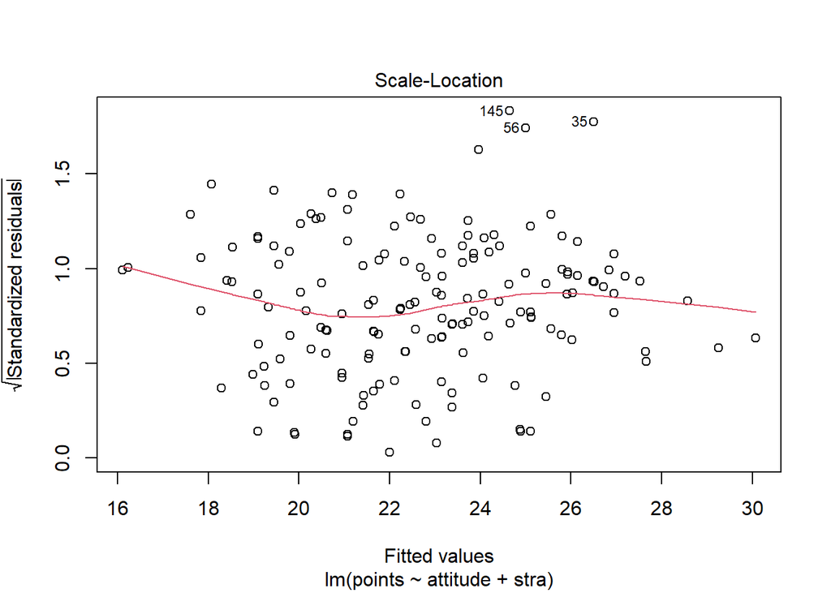

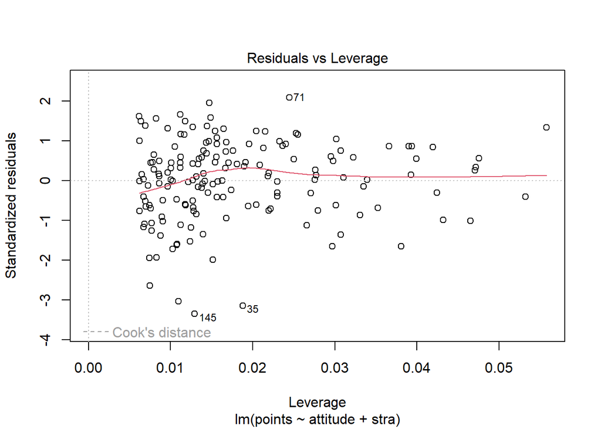

```r
plot(final_model)
```

#### The assumptions of linear regression model:

First, linear regression needs the relationship between the independent and dependent variables to be linear. Secondly, the linear regression analysis requires all variables to be multivariate normal. Thirdly, linear regression assumes that there is little or no multicollinearity in the data. Fourth, linear regression analysis requires that there is little or no autocorrelation in the data.

#### Checking the model validation:

From the residuals vs Fitted value, we can not see clear skewness, so we can say that fitted values have been distributed throughout the plot.